# Risk Factor Analysis

## Outcome Variable

**Outcome Variable:** haz

## Predictor Variables

**Intervention Variable:** brthmon

**Adjustment Set:**

unadjusted

## Stratifying Variables

The analysis was stratified on these variable(s):

- agecat

## Data Summary

| agecat | brthmon | n_cell | n | outcome_variable |
| --- | --- | --- | --- | --- |
| Birth | 1 | 4818 | 59325 | haz |
| Birth | 2 | 4424 | 59325 | haz |
| Birth | 3 | 5035 | 59325 | haz |
| Birth | 4 | 4275 | 59325 | haz |
| Birth | 5 | 3876 | 59325 | haz |
| Birth | 6 | 4213 | 59325 | haz |
| Birth | 7 | 4783 | 59325 | haz |
| Birth | 8 | 5297 | 59325 | haz |
| Birth | 9 | 5500 | 59325 | haz |
| Birth | 10 | 5582 | 59325 | haz |
| Birth | 11 | 5614 | 59325 | haz |
| Birth | 12 | 5908 | 59325 | haz |
| 6 months | 1 | 4164 | 58290 | haz |
| 6 months | 2 | 4173 | 58290 | haz |
| 6 months | 3 | 5112 | 58290 | haz |
| 6 months | 4 | 4438 | 58290 | haz |
| 6 months | 5 | 4272 | 58290 | haz |
| 6 months | 6 | 4350 | 58290 | haz |
| 6 months | 7 | 5056 | 58290 | haz |
| 6 months | 8 | 5579 | 58290 | haz |
| 6 months | 9 | 5366 | 58290 | haz |
| 6 months | 10 | 5302 | 58290 | haz |
| 6 months | 11 | 5250 | 58290 | haz |
| 6 months | 12 | 5228 | 58290 | haz |
| 24 months | 1 | 1659 | 25706 | haz |
| 24 months | 2 | 2240 | 25706 | haz |
| 24 months | 3 | 2602 | 25706 | haz |
| 24 months | 4 | 2070 | 25706 | haz |
| 24 months | 5 | 1828 | 25706 | haz |
| 24 months | 6 | 1989 | 25706 | haz |
| 24 months | 7 | 2334 | 25706 | haz |
| 24 months | 8 | 2316 | 25706 | haz |
| 24 months | 9 | 2104 | 25706 | haz |
| 24 months | 10 | 2042 | 25706 | haz |
| 24 months | 11 | 2103 | 25706 | haz |
| 24 months | 12 | 2419 | 25706 | haz |

The following strata were considered:

- agecat: 24 months
- agecat: 6 months
- agecat: Birth

## Methods Detail

We’re interested in the causal parameters $E[Y_a]$ for all values of $a \in \mathcal{A}$. These parameters represent the mean outcome if, possibly contrary to fact, we intervened to set all units to have $A=a$. Under the randomization and positivity assumptions, these are identified by the statistical parameters $\psi_a=E_W[E_{Y|A,W}(Y|A=a,W)]$. In addition, we’re interested in the mean of $Y$, $E[Y]$ under no intervention (the observed mean). We will estimate these parameters by using SuperLearner to fit the relevant likelihood factors – $E_{Y|A,W}(Y|A=a,W)$ and $p(A=a|W)$, and then updating our likelihood fit using a joint TMLE.

For unadjusted analyses ($W=\{\}$), initial likelihoods were estimated using Lrnr_glm to estimate the simple $E(Y|A)$ and Lrnr_mean to estimate $p(A)$. For adjusted analyses, a small library containing Lrnr_glmnet, Lrnr_xgboost, and Lrnr_mean was used.

Having estimated these parameters, we will then use the delta method to estimate relative risks and attributable risks relative to a prespecified baseline level of $A$.

# Results Detail

## Results Plots

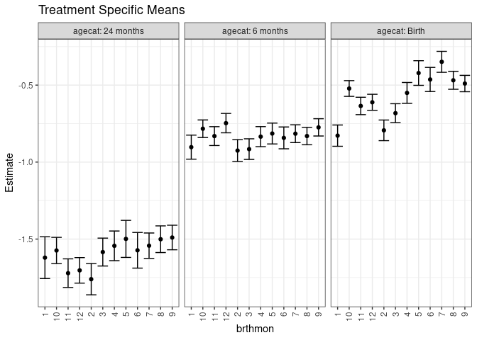

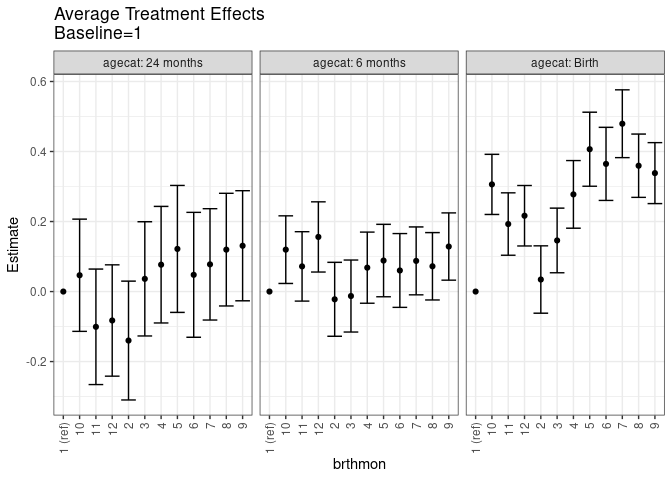

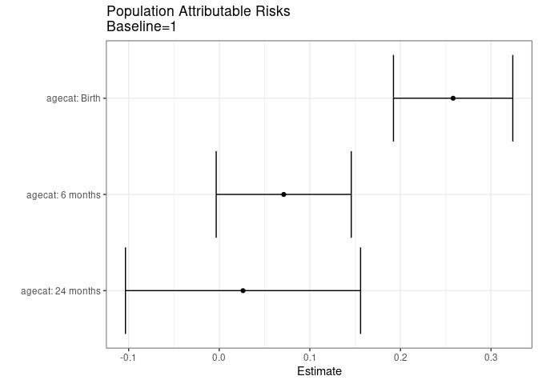

## Results Table

### Parameter: TSM

| agecat | intervention_level | baseline_level | estimate | ci_lower | ci_upper |
| --- | --- | --- | --- | --- | --- |
| Birth | 1 | NA | -0.8280552 | -0.8971622 | -0.7589482 |
| Birth | 2 | NA | -0.7936551 | -0.8606706 | -0.7266396 |
| Birth | 3 | NA | -0.6821033 | -0.7433902 | -0.6208164 |
| Birth | 4 | NA | -0.5505170 | -0.6181473 | -0.4828866 |
| Birth | 5 | NA | -0.4214590 | -0.5015467 | -0.3413713 |
| Birth | 6 | NA | -0.4633954 | -0.5417303 | -0.3850606 |
| Birth | 7 | NA | -0.3486787 | -0.4167686 | -0.2805887 |
| Birth | 8 | NA | -0.4686275 | -0.5270259 | -0.4102291 |
| Birth | 9 | NA | -0.4897364 | -0.5428533 | -0.4366194 |
| Birth | 10 | NA | -0.5219635 | -0.5730834 | -0.4708435 |
| Birth | 11 | NA | -0.6351986 | -0.6915542 | -0.5788431 |
| Birth | 12 | NA | -0.6114954 | -0.6634412 | -0.5595497 |
| 6 months | 1 | NA | -0.9029113 | -0.9809824 | -0.8248402 |
| 6 months | 2 | NA | -0.9250543 | -0.9961291 | -0.8539795 |
| 6 months | 3 | NA | -0.9157034 | -0.9826098 | -0.8487970 |
| 6 months | 4 | NA | -0.8346629 | -0.8996842 | -0.7696416 |
| 6 months | 5 | NA | -0.8143549 | -0.8822067 | -0.7465032 |
| 6 months | 6 | NA | -0.8427070 | -0.9135774 | -0.7718366 |
| 6 months | 7 | NA | -0.8153499 | -0.8731673 | -0.7575324 |
| 6 months | 8 | NA | -0.8307458 | -0.8873111 | -0.7741805 |
| 6 months | 9 | NA | -0.7742929 | -0.8304041 | -0.7181817 |
| 6 months | 10 | NA | -0.7832098 | -0.8402159 | -0.7262037 |
| 6 months | 11 | NA | -0.8310482 | -0.8921645 | -0.7699320 |
| 6 months | 12 | NA | -0.7468867 | -0.8098107 | -0.6839627 |
| 24 months | 1 | NA | -1.6205957 | -1.7564108 | -1.4847806 |
| 24 months | 2 | NA | -1.7605238 | -1.8623253 | -1.6587223 |
| 24 months | 3 | NA | -1.5842890 | -1.6749127 | -1.4936653 |
| 24 months | 4 | NA | -1.5438370 | -1.6401222 | -1.4475518 |
| 24 months | 5 | NA | -1.4988259 | -1.6191218 | -1.3785299 |
| 24 months | 6 | NA | -1.5728053 | -1.6885490 | -1.4570615 |
| 24 months | 7 | NA | -1.5429329 | -1.6253951 | -1.4604708 |
| 24 months | 8 | NA | -1.5008788 | -1.5874168 | -1.4143408 |
| 24 months | 9 | NA | -1.4897983 | -1.5694881 | -1.4101086 |
| 24 months | 10 | NA | -1.5740380 | -1.6591525 | -1.4889235 |
| 24 months | 11 | NA | -1.7213199 | -1.8142186 | -1.6284212 |
| 24 months | 12 | NA | -1.7032179 | -1.7860065 | -1.6204293 |

### Parameter: E(Y)

| agecat | intervention_level | baseline_level | estimate | ci_lower | ci_upper |
| --- | --- | --- | --- | --- | --- |
| Birth | NA | NA | -0.5699171 | -0.5881824 | -0.5516518 |
| 6 months | NA | NA | -0.8317427 | -0.8502227 | -0.8132627 |
| 24 months | NA | NA | -1.5943496 | -1.6222631 | -1.5664360 |

### Parameter: ATE

| agecat | intervention_level | baseline_level | estimate | ci_lower | ci_upper |
| --- | --- | --- | --- | --- | --- |
| Birth | 1 | 1 | 0.0000000 | 0.0000000 | 0.0000000 |
| Birth | 2 | 1 | 0.0344001 | -0.0618447 | 0.1306450 |
| Birth | 3 | 1 | 0.1459519 | 0.0536422 | 0.2382616 |
| Birth | 4 | 1 | 0.2775383 | 0.1809396 | 0.3741369 |
| Birth | 5 | 1 | 0.4065962 | 0.3008910 | 0.5123014 |
| Birth | 6 | 1 | 0.3646598 | 0.2602172 | 0.4691023 |
| Birth | 7 | 1 | 0.4793766 | 0.3825155 | 0.5762376 |
| Birth | 8 | 1 | 0.3594277 | 0.2690172 | 0.4498381 |
| Birth | 9 | 1 | 0.3383188 | 0.2512172 | 0.4254205 |
| Birth | 10 | 1 | 0.3060918 | 0.2202188 | 0.3919648 |
| Birth | 11 | 1 | 0.1928566 | 0.1037223 | 0.2819909 |
| Birth | 12 | 1 | 0.2165598 | 0.1301665 | 0.3029530 |
| 6 months | 1 | 1 | 0.0000000 | 0.0000000 | 0.0000000 |
| 6 months | 2 | 1 | -0.0221430 | -0.1277239 | 0.0834379 |
| 6 months | 3 | 1 | -0.0127921 | -0.1156204 | 0.0900362 |
| 6 months | 4 | 1 | 0.0682484 | -0.0333319 | 0.1698287 |
| 6 months | 5 | 1 | 0.0885564 | -0.0148679 | 0.1919806 |
| 6 months | 6 | 1 | 0.0602043 | -0.0451957 | 0.1656043 |
| 6 months | 7 | 1 | 0.0875614 | -0.0094302 | 0.1845530 |
| 6 months | 8 | 1 | 0.0721655 | -0.0240866 | 0.1684175 |
| 6 months | 9 | 1 | 0.1286184 | 0.0325609 | 0.2246760 |
| 6 months | 10 | 1 | 0.1197015 | 0.0230774 | 0.2163256 |
| 6 months | 11 | 1 | 0.0718631 | -0.0272660 | 0.1709922 |
| 6 months | 12 | 1 | 0.1560246 | 0.0558138 | 0.2562355 |
| 24 months | 1 | 1 | 0.0000000 | 0.0000000 | 0.0000000 |
| 24 months | 2 | 1 | -0.1399281 | -0.3096474 | 0.0297912 |
| 24 months | 3 | 1 | 0.0363067 | -0.1268008 | 0.1994143 |
| 24 months | 4 | 1 | 0.0767588 | -0.0897060 | 0.2432236 |
| 24 months | 5 | 1 | 0.1217699 | -0.0595194 | 0.3030591 |
| 24 months | 6 | 1 | 0.0477905 | -0.1305919 | 0.2261728 |
| 24 months | 7 | 1 | 0.0776628 | -0.0813358 | 0.2366614 |
| 24 months | 8 | 1 | 0.1197169 | -0.0411934 | 0.2806272 |
| 24 months | 9 | 1 | 0.1307974 | -0.0264403 | 0.2880351 |
| 24 months | 10 | 1 | 0.0465577 | -0.1137569 | 0.2068723 |
| 24 months | 11 | 1 | -0.1007242 | -0.2656844 | 0.0642360 |
| 24 months | 12 | 1 | -0.0826222 | -0.2416237 | 0.0763794 |

### Parameter: PAR

| agecat | intervention_level | baseline_level | estimate | ci_lower | ci_upper |
| --- | --- | --- | --- | --- | --- |
| Birth | 1 | NA | 0.2581381 | 0.1922900 | 0.3239863 |
| 6 months | 1 | NA | 0.0711686 | -0.0033603 | 0.1456975 |
| 24 months | 1 | NA | 0.0262462 | -0.1034986 | 0.1559910 |